# IODS course project

Ulla Suulamo

# Introduction to Open Data Science - Course Project

This is a course diary for *Introduction to Open Data Science*, November-December 2022.

# Week 1

With mixed feelings at the moment. I am glad I managed to take this course this year but I am anticipating busy weeks and I am worried I won’t have as much time to dedicate to the course as I would like, without sacrificing too many hours of sleep or family time with kids. But I am hoping to get more used to working with R and I believe every extra hour counts so I’ll just try to do my best to keep up with the pace of the course.

I have not yet reached the end of chapter 4 of the **R for Health Data Science** book, but at least for someone like me (I have used R before but not much or regularly) I think it is working quite well as a fresh up.

**GitHub repository:** https://github.com/ullasuu/IODS-project

```r
date()
```

```
## [1] "Sun Dec 11 13:14:29 2022"
```

# Week 2. Regression and model validation

This is the report for the second week assignment (the analysis part of the assignment in particular).

```r
date()
```

```
## [1] "Sun Dec 11 13:14:29 2022"
```

Load needed packages:

```r
library(tidyverse)
library(finalfit)
library(ggplot2)
library(GGally)
library(patchwork)
```

### 1. Read in data

I read the data from my local folder. (I hope it is as it should!)

```r
lrn2014 <- read_csv("data/learning2014.csv")
```

```r
str(lrn2014)
```

```
## spc_tbl_ [166 × 7] (S3: spec_tbl_df/tbl_df/tbl/data.frame)
##  $ gender  : chr [1:166] "F" "M" "F" "M" ...
##  $ age     : num [1:166] 53 55 49 53 49 38 50 37 37 42 ...
##  $ attitude: num [1:166] 3.7 3.1 2.5 3.5 3.7 3.8 3.5 2.9 3.8 2.1 ...
##  $ deep    : num [1:166] 3.58 2.92 3.5 3.5 3.67 ...
##  $ stra    : num [1:166] 3.38 2.75 3.62 3.12 3.62 ...
##  $ surf    : num [1:166] 2.58 3.17 2.25 2.25 2.83 ...
##  $ points  : num [1:166] 25 12 24 10 22 21 21 31 24 26 ...
##  - attr(*, "spec")=
##   .. cols(
##   ..   gender = col_character(),
##   ..   age = col_double(),
##   ..   attitude = col_double(),
##   ..   deep = col_double(),
##   ..   stra = col_double(),
##   ..   surf = col_double(),
##   ..   points = col_double()
##   .. )
##  - attr(*, "problems")=<externalptr>
```

```r
ff_glimpse(lrn2014)
```

```
## $Continuous
##             label var_type   n missing_n missing_percent mean  sd  min
## age           age    <dbl> 166         0             0.0 25.5 7.8 17.0
## attitude attitude    <dbl> 166         0             0.0  3.1 0.7  1.4
## deep         deep    <dbl> 166         0             0.0  3.7 0.6  1.6
## stra         stra    <dbl> 166         0             0.0  3.1 0.8  1.2
## surf         surf    <dbl> 166         0             0.0  2.8 0.5  1.6
## points     points    <dbl> 166         0             0.0 22.7 5.9  7.0
##          quartile_25 median quartile_75  max
## age             21.0   22.0        27.0 55.0
## attitude         2.6    3.2         3.7  5.0
## deep             3.3    3.7         4.1  4.9
## stra             2.6    3.2         3.6  5.0
## surf             2.4    2.8         3.2  4.3
## points          19.0   23.0        27.8 33.0
##
## $Categorical
##         label var_type   n missing_n missing_percent levels_n levels
## gender gender    <chr> 166         0             0.0        2      -
##        levels_count levels_percent
## gender            -              -
```

The exercise is based on survey data which was collected in 2014 from students participating in the statistics course *Introduction to Social Statistics*. The data contains information on students exam points and attitudes towards statistics and learning.

The dataset has 166 observations (rows) of 7 variables (columns) of which 1 is character and 6 numerical. There are no missing values. Students ages range between 17 and 55 years.

### 2. Overview of data

The plot matrix visualizes the distributions of the variables (diagonal), and the plotted relationships and correlations between them, for women (in **red**) and men (in **turquoise**) separately.

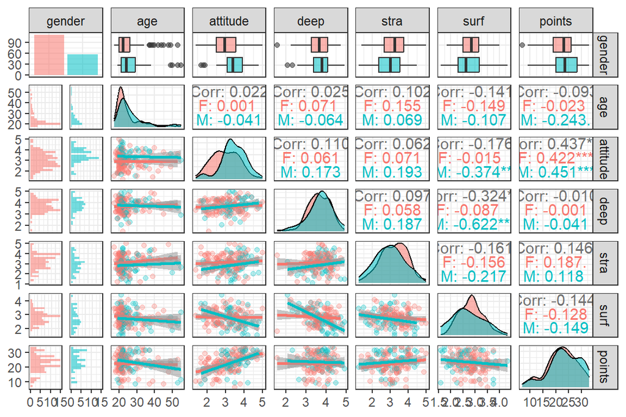

```r
ggpairs(lrn2014, mapping = aes(col = gender, alpha = 0.3), lower = list(continuous = wrap("smooth", alpha = 0.3, size=1.5), combo = wrap("facethist", bins = 20)), progress = F) +
  theme_bw()
```

Some observations from the plot: Both the correlations and scatterplots show that a positive relationship appears to exist between students attitudes and their statistics course exam points, i.e. those with a more positive attitude towards learning seem to do better. Men’s attitudes seem slightly higher compared to women’s.

Looking at the correlations, there is a weak negative correlation between exam points and age, and exam points and scores of surface learning, whereas scores of strategic learning and exam points seem to correlate positively. Moreover, especially for men, scores of deep learning correlate negatively with scores related to surface learning, which seems quite logical.

We can also see that there are more females than males and that despite the wide age range, most of the students are below age 30: the mean age is 26, as can be seen below.

```r
lrn2014$age %>% mean()
```

```
## [1] 25.51205
```

Overall, the exam points of all students vary between a maximum of 33 and minimum on 7 but the density plot and boxplot above suggest the distribution of points is not that normal but instead skewed towards left.

```r
lrn2014$points %>% min()
```

```
## [1] 7
```

```r
lrn2014$points %>% max()
```

```
## [1] 33
```

### 3. Regression model

I choose attitude, strategic learning and surface learning as the explanatory variables of points and fit the following model:

```r
model1 <- lm(points ~ attitude + stra + surf, data = lrn2014)
summary(model1)  # Check model fit
```

```
##
## Call:
## lm(formula = points ~ attitude + stra + surf, data = lrn2014)
##
## Residuals:
##      Min       1Q   Median       3Q      Max
## -17.1550  -3.4346   0.5156   3.6401  10.8952
##
## Coefficients:
##             Estimate Std. Error t value Pr(>|t|)
## (Intercept)  11.0171     3.6837   2.991  0.00322 **
## attitude      3.3952     0.5741   5.913 1.93e-08 ***
## stra          0.8531     0.5416   1.575  0.11716
## surf         -0.5861     0.8014  -0.731  0.46563
## ---
## Signif. codes:  0 '***' 0.001 '**' 0.01 '*' 0.05 '.' 0.1 ' ' 1
##
## Residual standard error: 5.296 on 162 degrees of freedom
## Multiple R-squared:  0.2074, Adjusted R-squared:  0.1927
## F-statistic: 14.13 on 3 and 162 DF,  p-value: 3.156e-08
```

The regression result suggests, that neither strategic nor surface learning have much effect and are not significant predictors of exam points. Only the slope estimate for attitude is significantly different from 0 here. All together, the three variables explain about one fifth of the variation in exam points. I drop the two non-significant explanatory variables and fit a new simple model:

```r
model2 <- lm(points ~ attitude, data = lrn2014)
summary(model2)  # Check model fit
```

```
##
## Call:
## lm(formula = points ~ attitude, data = lrn2014)
##
## Residuals:
##      Min       1Q   Median       3Q      Max
## -16.9763  -3.2119   0.4339   4.1534  10.6645
##
## Coefficients:
##             Estimate Std. Error t value Pr(>|t|)
## (Intercept)  11.6372     1.8303   6.358 1.95e-09 ***
## attitude      3.5255     0.5674   6.214 4.12e-09 ***
## ---
## Signif. codes:  0 '***' 0.001 '**' 0.01 '*' 0.05 '.' 0.1 ' ' 1
##
## Residual standard error: 5.32 on 164 degrees of freedom
## Multiple R-squared:  0.1906, Adjusted R-squared:  0.1856
## F-statistic: 38.61 on 1 and 164 DF,  p-value: 4.119e-09
```

### 4. Interpretation

The R-squared of the second model is 0.1906, almost the same as in the first model although two explanatory variables were removed. Overall, this model alone does not explain that much, but still around 19% of the variation in exam points is explained by the variation in attitude score. The slope estimate for attitude is 3.5, so by each unit increase in attitude score, the exam result increases by 3.5 points.

Below a scatterplot of the data with the fitted line.

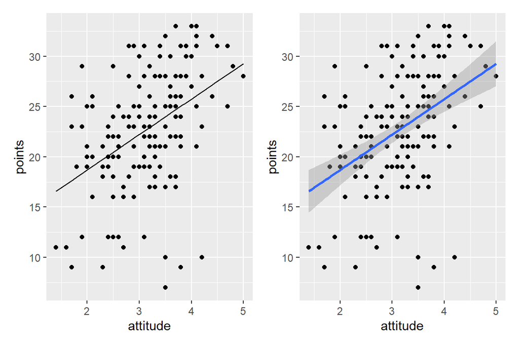

```r
p1 <- lrn2014 %>%
  ggplot() +
  geom_point(aes(x = attitude, y = points)) +
  geom_line(aes(x = attitude, y = predict(model2)))

p2 <- qplot(attitude, points, data = lrn2014) +
  geom_smooth(method = "lm")

p1 | p2
```

### 5. Diagnostic plots

The linear model assumes normal distribution of residuals. The normal Q-Q plot shows that residuals are more or less normally distributed, but still somewhat diverging from the straight line, especially towards the extremes.

The linear model also assumes equal variance of residuals. The plot of residuals vs fitted values seems quite reasonable and the residuals seem to be spread more or less randomly around the 0 line.

Residuals vs Leverage plot does not indicate any extreme problematic outliers with a high leverage value (?).

(I have not been looking much at these kinds of diagnostic plots and I find it quite difficult to really get what they mean and how to evaluate them reasonably.)

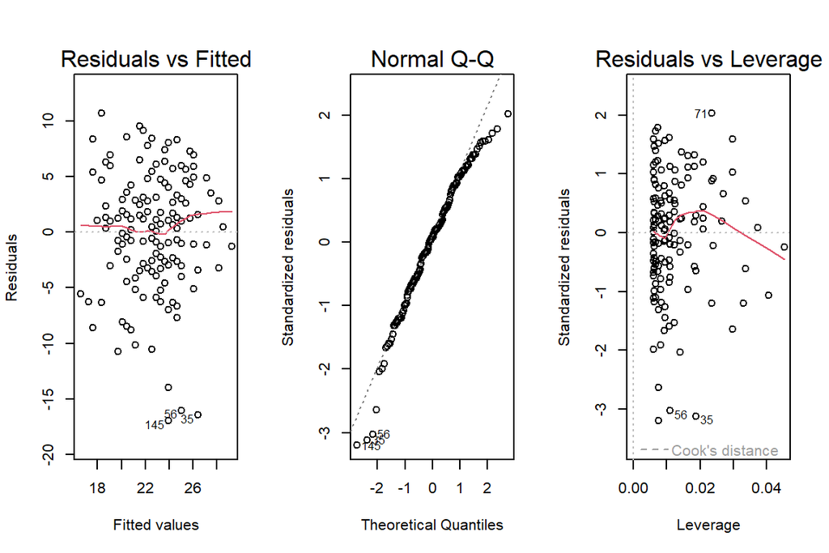

```r
par(mfrow = c(1,3))
plot(model2, which = c(1, 2, 5))
```

# Week 3. Logistic regression

Here is my report for the assignment of week three. I am starting a bit late so let’s see how far I get before running out of time.

```r
date()
```

```
## [1] "Sun Dec 11 13:14:44 2022"
```

Load needed packages:

```r
library(tidyverse); library(dplyr); library(ggplot2)
```

### 2. Read in data

I read the data from my local folder.

```r
alc <- read_csv("data/alc.csv")
```

The data used in the exercise contains information on student performance in two Portuguese secondary schools. The data is based on school reports and questionnaires and include info on grades, demographics, and school related characteristics, and for example, on alcohol consumption. Two separate datasets are available: performance in Mathematics (mat) and in Portuguese language (por). More information is available [here](https://archive.ics.uci.edu/ml/datasets/Student+Performance).

I check the column names

```r
colnames(alc)
```

```
##  [1] "school"     "sex"        "age"        "address"    "famsize"
##  [6] "Pstatus"    "Medu"       "Fedu"       "Mjob"       "Fjob"
## [11] "reason"     "guardian"   "traveltime" "studytime"  "schoolsup"
## [16] "famsup"     "activities" "nursery"    "higher"     "internet"
## [21] "romantic"   "famrel"     "freetime"   "goout"      "Dalc"
## [26] "Walc"       "health"     "failures"   "paid"       "absences"
## [31] "G1"         "G2"         "G3"         "alc_use"    "high_use"
```

and have a quick look on the data.

```r
glimpse(alc)
```

```
## Rows: 370
## Columns: 35
## $ school     <chr> "GP", "GP", "GP", "GP", "GP", "GP", "GP", "GP", "GP", "GP",…
## $ sex        <chr> "F", "F", "F", "F", "F", "M", "M", "F", "M", "M", "F", "F",…
## $ age        <dbl> 18, 17, 15, 15, 16, 16, 16, 17, 15, 15, 15, 15, 15, 15, 15,…
## $ address    <chr> "U", "U", "U", "U", "U", "U", "U", "U", "U", "U", "U", "U",…
## $ famsize    <chr> "GT3", "GT3", "LE3", "GT3", "GT3", "LE3", "LE3", "GT3", "LE…
## $ Pstatus    <chr> "A", "T", "T", "T", "T", "T", "T", "A", "A", "T", "T", "T",…
## $ Medu       <dbl> 4, 1, 1, 4, 3, 4, 2, 4, 3, 3, 4, 2, 4, 4, 2, 4, 4, 3, 3, 4,…
## $ Fedu       <dbl> 4, 1, 1, 2, 3, 3, 2, 4, 2, 4, 4, 1, 4, 3, 2, 4, 4, 3, 2, 3,…
## $ Mjob       <chr> "at_home", "at_home", "at_home", "health", "other", "servic…
## $ Fjob       <chr> "teacher", "other", "other", "services", "other", "other", …
## $ reason     <chr> "course", "course", "other", "home", "home", "reputation", …
## $ guardian   <chr> "mother", "father", "mother", "mother", "father", "mother",…
## $ traveltime <dbl> 2, 1, 1, 1, 1, 1, 1, 2, 1, 1, 1, 3, 1, 2, 1, 1, 1, 3, 1, 1,…
```

[output cut: 22 more lines]

The data contain 35 variables and 370 observations.

### 3. Selection of predictors

One of the variables is a logical TRUE/FALSE variable on high use of alcohol. This is the target variable of interest in this exercise. To study the relationships between high/low alcohol consumption and some other characteristics I select the following and my hypothesis are:

**Sex** - I hypothesize that there are more high users among men.

**Study time** - I hypothesize that those who study more are perhaps more focused and motivated and consequently use less alcohol.

**Going out with friends** - My hypothesis is that students who go out more consume more alcohol and are thus more likely to be high users.

**Extra-curricular activities** - Leisure time activities may be associated with a healthier lifestyle and mean there is less time for drinking. I hypothesize that students with extra-curricular activities are less likely to be heavy drinkers.